# Scraping HTML data from the web

Mahbubul Majumder, PhD  
Oct 28, 2020

### Sources of data online

- Each web site is a source of data
- Three ways to obtain data from the web
  1. we already worked on how to get entire web site into `R` and look for useful information
  2. scraping data from HTML tables or other tags
  3. using API provided by respective data sources
- Web data could be structured or unstructured or semi-structured
  - plain texts are usually unstructured
  - HTML tables are usually structured
- Sources of data through API
  - twitter, Facebook or other social or professional media or blog
  - mostly unstructured, but there may be intrinsic structure
  - some times very useful and interesting

### Data in HTML documents

- Often we see data in HTML tables
  - sports or crimes or others statistics
- How would you get data from an HTML table
  - copy the data and paste in Excel (demonstration: get data from nfl.com)
  - Excel is very useful, every one should learn it
  - but it could be very tricky to handle large data table
  - manual operation is always risky
- Fortunately we can do it automatically using package `XML`

```r
# install.packages("XML")
library(XML)
# install.packages("RCurl")
library(RCurl)
```

### Scraping HTML tables

- First inspect the data by going to the HTML link
  - chrome has nice features to do that
  - write click on the page and select inspect element
  - can examine all the tags, attributes and values
- As you scroll your mouse over the elements it will highlight in the page
  - go to the respective table which contains the data
  - get the id for that table
- Demonstration with getting data from wikipedia
  - search the list of countries in the world

### Case Study: Gathering data from web site

```r
u1 <- "https://en.wikipedia.org/wiki/"
u2 <- "List_of_countries_and_dependencies_by_population"
url <- getURL(paste0(u1,u2))
tables <- readHTMLTable(url, header=TRUE)
head(tables[[1]])
```

```
  Rank Country(or dependent territory)    Population % of world
1    1                        China[b] 1,405,064,840      18.0%
2    2                        India[c] 1,368,951,139      17.5%
3    3                United States[d]   330,550,110      4.23%
4    4                       Indonesia   269,603,400      3.45%
5    5                     Pakistan[e]   220,892,331      2.82%
6    6                          Brazil   212,259,030      2.71%
         Date      Source(official or UN)\n
1 28 Oct 2020  National population clock[3]
2 28 Oct 2020  National population clock[4]
3 28 Oct 2020  National population clock[5]
4  1 Jul 2020 National annual projection[6]
5  1 Jul 2020              UN Projection[2]
6 28 Oct 2020  National population clock[7]
```

### Case study: Gathering data from worldometer

```r
u <- "https://www.worldometers.info/geography/alphabetical-list-of-countries/"
url1 <- getURL(u)
tables1 <- readHTMLTable(url1, header=TRUE)
tables1[[1]][1:15,2:4]
```

```
               Country Population(2020) Land Area (Km²)
1          Afghanistan       38,928,346         652,860
2              Albania        2,877,797          27,400
3              Algeria       43,851,044       2,381,740
4              Andorra           77,265             470
5               Angola       32,866,272       1,246,700
6  Antigua and Barbuda           97,929             440
7            Argentina       45,195,774       2,736,690
8              Armenia        2,963,243          28,470
9            Australia       25,499,884       7,682,300
10             Austria        9,006,398          82,409
11          Azerbaijan       10,139,177          82,658
12             Bahamas          393,244          10,010
13             Bahrain        1,701,575             760
14          Bangladesh      164,689,383         130,170
15            Barbados          287,375             430
```

### Scrapping data using rvest

- `xml2` and `rvest` work together nice

```r
# install.packages("rvest")
library(rvest)
```

- Try the following codes

```r
demo(zillow, package = "rvest")
```

- Search google for `rvest demo`

### Gathering twitter data

- twitter provides API to obtain tweets information
- Use `R` package `twitteR` to extract and work with twitter data
  - you can search specific tweets by person, location, topic etc.
  - analyse re-tweets
  - install `twitteR` from `github` not `CRAN` what you usually do
- twitter data some times provides interesting information about current incidents
- Challenge is how to handle various languages and grammar or spelling
  - some times it is highly misleading to decide based on one language
  - in tweets many people don't care about spelling or mixing language

### Setting up twitter API

- First create a twitter account
  - create a new application from https://apps.twitter.com/
  - will provide you with API keys and secrets
- Now run the following codes from `R` (for details https://github.com/geoffjentry/twitteR/)

```r
#install.packages(c("devtools", "rjson", "bit64", "httr", "base64enc"))
library(devtools)
#install_github("geoffjentry/twitteR")
library(twitteR)

api_key <- "your api key"
api_secret <- "your api secret"
access_token <- "your access tocken"
access_token_secret <- "your access tocken secret"

setup_twitter_oauth(api_key,api_secret,access_token,
                    access_token_secret)
```

```
[1] "Using direct authentication"
```

### Case Study: Getting the tweets about data science

```r
dsTweet <- searchTwitter("data science")
dfTweet <- twListToDF(dsTweet)
tweetText <- dfTweet$text
head(tweetText)
```

```
[1] "RT @armab_io: \"Developers bridging Communities\".\n\nSome really nice data-driven analysis presentation of CNCF ecosystem at #OSSummit. Pink d…"
[2] "\"Developers bridging Communities\".\n\nSome really nice data-driven analysis presentation of CNCF ecosystem at… https://t.co/fxNcTTezEN"
[3] "RT @jpsenescence: I'm delighted to announce my company, Magellan Science Ltd, to provide consulting in longevity science. Please browse our…"
[4] "RT @SWAtlasHoover: Epic failure of \"experts\" Death cert: “social isolation/fail. to thrive rel'd to COVID-19 restrictions.”  Nh res: “I wou…"
[5] "RT @jpsenescence: I'm delighted to announce my company, Magellan Science Ltd, to provide consulting in longevity science. Please browse our…"
[6] "RT @rmc031: For months I’ve followed debates, protests, plans and research around school re-openings. People desperately want science + dat…"
```

### Case Study: tweets of Dr. Sanjay Gupta

```r
user <- getUser("drsanjaygupta")
sanjay <- userTimeline(user, n=500)
snDf <- twListToDF(sanjay)
snText <- snDf$text
library(stringr)
snWords <- str_extract_all(snText, '(\\w+)')
head(snWords)
```

```
[[1]]
 [1] "I"             "was"           "with"          "StephenAtHome"
 [5] "back"          "on"            "March"         "13"
 [9] "right"         "as"            "a"             "pandemic"
[13] "was"           "being"         "declared"      "It"
[17] "was"           "the"           "last"          "https"
[21] "t"             "co"            "5KlCpe15NI"

[[2]]
 [1] "My"         "beloved"    "umich"      "wolverines" "are"
 [6] "about"      "to"         "play"       "their"      "first"
[11] "game"       "I"          "love"       "football"   "but"
[16] "we"         "are"        "in"         "the"        "middle"
[21] "of"         "a"          "https"      "t"          "co"
[26] "9nD8DZOFaV"
```

[output cut: 31 more lines]

### Case Study: Hashtags in Dr. Sanjay Gupta's tweets

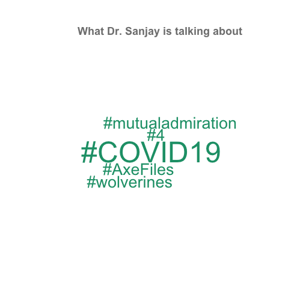

```r
snHashtags = str_extract_all(snDf$text, "#\\w+")
freq <- table(unlist(snHashtags))

library(wordcloud)
wordcloud(names(freq), freq, random.order=FALSE, colors="#1B9E77")
title("\n\nWhat Dr. Sanjay is talking about",
    cex.main=1.5, col.main="gray50")
```

### Sources of tweets

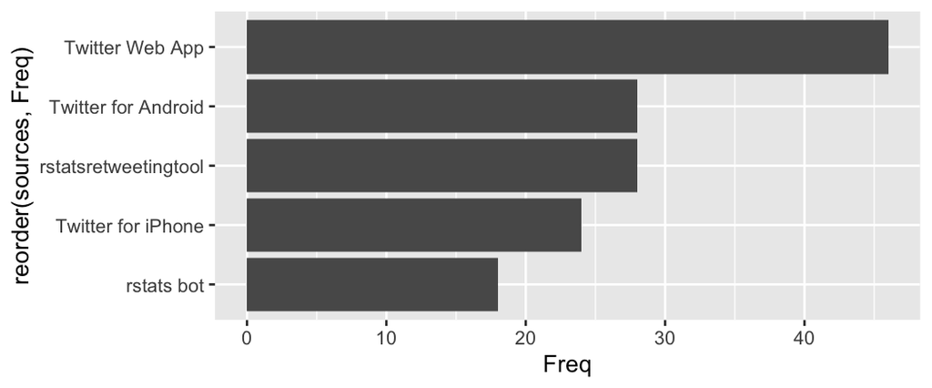

```r
r_tweets <- searchTwitter("#rstats", n=300)
sources <- sapply(r_tweets, function(x) x$getStatusSource())
sources <- gsub("</a>", "", sources)
sources <- strsplit(sources, ">")
sources <- sapply(sources, function(x) ifelse(length(x) > 1, x[2], x[1]))
source_table = table(sources)
df <- data.frame(names(source_table),source_table)
ggplot(df[df$Freq>8,], aes(reorder(sources,Freq),Freq)) +
  geom_bar(stat="identity") + coord_flip()
```

### Reading assignment and references

- For details about setting up `twitteR` package in `R`  
  https://github.com/geoffjentry/twitteR/
- For examples of `twitteR` functions and what this package can deliver visit  
  http://geoffjentry.hexdump.org/twitteR.pdf
- For examples of `rvest` functions and what this package can deliver visit  
  https://blog.rstudio.com/2014/11/24/rvest-easy-web-scraping-with-r/